# Decoding the Enigma: Global Life Expectancy Trends Unveiled (2000-2015)

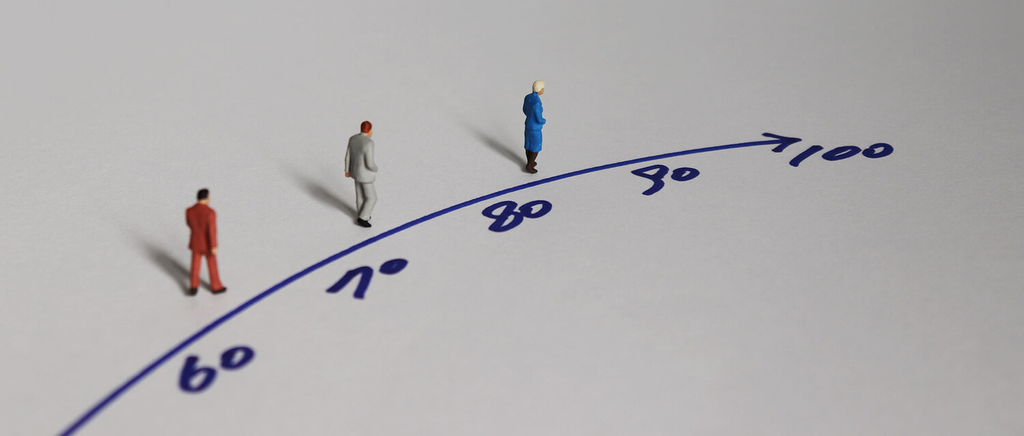

Life Expectancy

This project aims to analyze global life expectancy trends from 2000 to 2015, recognizing its significance as a measure of a country’s overall health and well-being. By examining various factors such as income, education, healthcare expenditure, disease prevalence, and lifestyle habits, we seek to identify the key drivers behind the improvements in life expectancy observed over the past two decades. The dataset used comprises 2938 observations, providing a rich source of information for assessing changes in life expectancy over time.

Our analysis will explore the relationship between life expectancy and factors like adult and infant mortality, alcohol consumption, healthcare expenditure, and education to determine their impact on lifespan.

We will investigate whether countries with low life expectancy should for example, prioritize increasing healthcare expenditure to improve average lifespan. Additionally, we will examine trends of diseases such as Polio and Measles, as well as the effects of thinness and malnutrition around the world.

The main objective of this article is determining the significance of various predictors on life expectancy and identifying the variables that have the strongest influence on lifespan. Furthermore, we will investigate the relationship between education and lifespan, assessing whether schooling has a positive or negative effect on life expectancy.

The insights gained from this project can inform social and public health systems and guide organizations in implementing changes that promote longer, healthier lives worldwide. The dataset used in this project is publicly available from the World Health Organization (WHO).

Through this comprehensive analysis, we aim to enhance our understanding of the global factors driving life expectancy trends and identify areas for improvement to foster better health outcomes for all.

This analysis will be conducted entirely with the statistical programming language: R.

Below is the structure and a summary of our dataset:

```
## 'data.frame':    2938 obs. of  22 variables:
##  $ Country                        : chr  "Afghanistan" "Afghanistan" "Afghanistan" "Afghanistan" ...
##  $ Year                           : int  2015 2014 2013 2012 2011 2010 2009 2008 2007 2006 ...
##  $ Status                         : chr  "Developing" "Developing" "Developing" "Developing" ...
##  $ Life.expectancy                : num  65 59.9 59.9 59.5 59.2 58.8 58.6 58.1 57.5 57.3 ...
##  $ Adult.Mortality                : int  263 271 268 272 275 279 281 287 295 295 ...
##  $ infant.deaths                  : int  62 64 66 69 71 74 77 80 82 84 ...
##  $ Alcohol                        : num  0.01 0.01 0.01 0.01 0.01 0.01 0.01 0.03 0.02 0.03 ...
##  $ percentage.expenditure         : num  71.3 73.5 73.2 78.2 7.1 ...
##  $ Hepatitis.B                    : int  65 62 64 67 68 66 63 64 63 64 ...
##  $ Measles                        : int  1154 492 430 2787 3013 1989 2861 1599 1141 1990 ...
##  $ BMI                            : num  19.1 18.6 18.1 17.6 17.2 16.7 16.2 15.7 15.2 14.7 ...
##  $ under.five.deaths              : int  83 86 89 93 97 102 106 110 113 116 ...
##  $ Polio                          : int  6 58 62 67 68 66 63 64 63 58 ...
##  $ Total.expenditure              : num  8.16 8.18 8.13 8.52 7.87 9.2 9.42 8.33 6.73 7.43 ...
##  $ Diphtheria                     : int  65 62 64 67 68 66 63 64 63 58 ...
##  $ HIV.AIDS                       : num  0.1 0.1 0.1 0.1 0.1 0.1 0.1 0.1 0.1 0.1 ...
##  $ GDP                            : num  584.3 612.7 631.7 670 63.5 ...
##  $ Population                     : num  33736494 327582 31731688 3696958 2978599 ...
##  $ thinness..1.19.years           : num  17.2 17.5 17.7 17.9 18.2 18.4 18.6 18.8 19 19.2 ...
##  $ thinness.5.9.years             : num  17.3 17.5 17.7 18 18.2 18.4 18.7 18.9 19.1 19.3 ...
##  $ Income.composition.of.resources: num  0.479 0.476 0.47 0.463 0.454 0.448 0.434 0.433 0.415 0.405 ...
##  $ Schooling                      : num  10.1 10 9.9 9.8 9.5 9.2 8.9 8.7 8.4 8.1 ...
```

```
##    Country               Year         Status          Life.expectancy
##  Length:2938        Min.   :2000   Length:2938        Min.   :36.30
##  Class :character   1st Qu.:2004   Class :character   1st Qu.:63.10
##  Mode  :character   Median :2008   Mode  :character   Median :72.10
##                     Mean   :2008                      Mean   :69.22
##                     3rd Qu.:2012                      3rd Qu.:75.70
##                     Max.   :2015                      Max.   :89.00
##                                                       NA's   :10
##  Adult.Mortality infant.deaths       Alcohol        percentage.expenditure
##  Min.   :  1.0   Min.   :   0.0   Min.   : 0.0100   Min.   :    0.000
##  1st Qu.: 74.0   1st Qu.:   0.0   1st Qu.: 0.8775   1st Qu.:    4.685
##  Median :144.0   Median :   3.0   Median : 3.7550   Median :   64.913
##  Mean   :164.8   Mean   :  30.3   Mean   : 4.6029   Mean   :  738.251
##  3rd Qu.:228.0   3rd Qu.:  22.0   3rd Qu.: 7.7025   3rd Qu.:  441.534
##  Max.   :723.0   Max.   :1800.0   Max.   :17.8700   Max.   :19479.912
##  NA's   :10                       NA's   :194
##   Hepatitis.B       Measles              BMI        under.five.deaths
##  Min.   : 1.00   Min.   :     0.0   Min.   : 1.00   Min.   :   0.00
##  1st Qu.:77.00   1st Qu.:     0.0   1st Qu.:19.30   1st Qu.:   0.00
##  Median :92.00   Median :    17.0   Median :43.50   Median :   4.00
##  Mean   :80.94   Mean   :  2419.6   Mean   :38.32   Mean   :  42.04
##  3rd Qu.:97.00   3rd Qu.:   360.2   3rd Qu.:56.20   3rd Qu.:  28.00
##  Max.   :99.00   Max.   :212183.0   Max.   :87.30   Max.   :2500.00
##  NA's   :553                        NA's   :34
##      Polio       Total.expenditure   Diphtheria       HIV.AIDS
##  Min.   : 3.00   Min.   : 0.370    Min.   : 2.00   Min.   : 0.100
##  1st Qu.:78.00   1st Qu.: 4.260    1st Qu.:78.00   1st Qu.: 0.100
##  Median :93.00   Median : 5.755    Median :93.00   Median : 0.100
##  Mean   :82.55   Mean   : 5.938    Mean   :82.32   Mean   : 1.742
##  3rd Qu.:97.00   3rd Qu.: 7.492    3rd Qu.:97.00   3rd Qu.: 0.800
##  Max.   :99.00   Max.   :17.600    Max.   :99.00   Max.   :50.600
##  NA's   :19      NA's   :226       NA's   :19
##       GDP              Population         thinness..1.19.years
##  Min.   :     1.68   Min.   :        34   Min.   : 0.10
##  1st Qu.:   463.94   1st Qu.:    195793   1st Qu.: 1.60
##  Median :  1766.95   Median :   1386542   Median : 3.30
##  Mean   :  7483.16   Mean   :  12753375   Mean   : 4.84
##  3rd Qu.:  5910.81   3rd Qu.:   7420359   3rd Qu.: 7.20
##  Max.   :119172.74   Max.   :1293859294   Max.   :27.70
##  NA's   :448         NA's   :652          NA's   :34
##  thinness.5.9.years Income.composition.of.resources   Schooling
##  Min.   : 0.10      Min.   :0.0000                  Min.   : 0.00
##  1st Qu.: 1.50      1st Qu.:0.4930                  1st Qu.:10.10
##  Median : 3.30      Median :0.6770                  Median :12.30
##  Mean   : 4.87      Mean   :0.6276                  Mean   :11.99
##  3rd Qu.: 7.20      3rd Qu.:0.7790                  3rd Qu.:14.30
##  Max.   :28.60      Max.   :0.9480                  Max.   :20.70
##  NA's   :34         NA's   :167                     NA's   :163
```

We will conduct some data cleaning by formatting all our column names to lower cases and replacing spaces with underscores. Our dataset does not have a continent column where each country’s continent can be referenced so we will also create 6 vectors for the six continents containing all countries in them and then we will use a custom function to assign a continent to each country in our dataframe.

From our dataset, we have 2,938 rows and 22 columns.

### PLOTS

First and foremost, we want to visualize the average life expectancy range over the 16 year period our dataset covers. We would like to infer if there has been any dramatic, normal or negative change in life expectancy rate around the world.

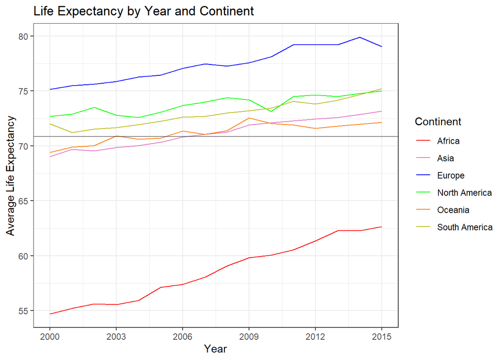

We see in our plot above that life expectancy rates have steadily gone up around the world. This positive trend indicates significant improvements in global health outcomes over the years. Several factors have contributed to the increase in life expectancy, including advancements in medical technology, improvements in healthcare infrastructure, better access to healthcare services, and increased awareness of healthy lifestyle choices.

The upward trajectory of life expectancy is a testament to the efforts made in disease prevention, early detection, and effective treatment of various illnesses. Immunization programs, better sanitation practices, and improved nutrition have also played a vital role in extending life expectancy and reducing mortality rates.

Moreover, socioeconomic development and progress in education have contributed to better health outcomes. As societies become more prosperous and literate, individuals have greater access to resources and knowledge to make informed decisions about their health.

While the overall trend is positive, it is important to acknowledge that there are still disparities in life expectancy between different regions and populations. Socioeconomic inequalities, access to healthcare, and various social determinants of health continue to influence life expectancy rates in different parts of the world.

Understanding the factors that contribute to the increase in life expectancy globally allows us to develop targeted interventions and policies that can further improve health outcomes and promote longevity. By addressing the underlying determinants of health, we can work towards achieving equitable and sustainable improvements in life expectancy for all individuals worldwide.

#### Dvelopment Status

In our exploration of life expectancy, we aim to investigate the potential impact of a country’s development status on life expectancy. By employing a boxplot to visualize the data, we can gain valuable insights into the distribution of life expectancy values across the different categories: Developed and Developing.

As we delve deeper into the analysis, several intriguing questions arise. Does being classified as a developed country correlate with higher life expectancy rates? Are developing countries facing unique challenges that influence their life expectancy? Are there notable differences in healthcare systems, socioeconomic factors, or public health initiatives that contribute to varying life expectancy outcomes?

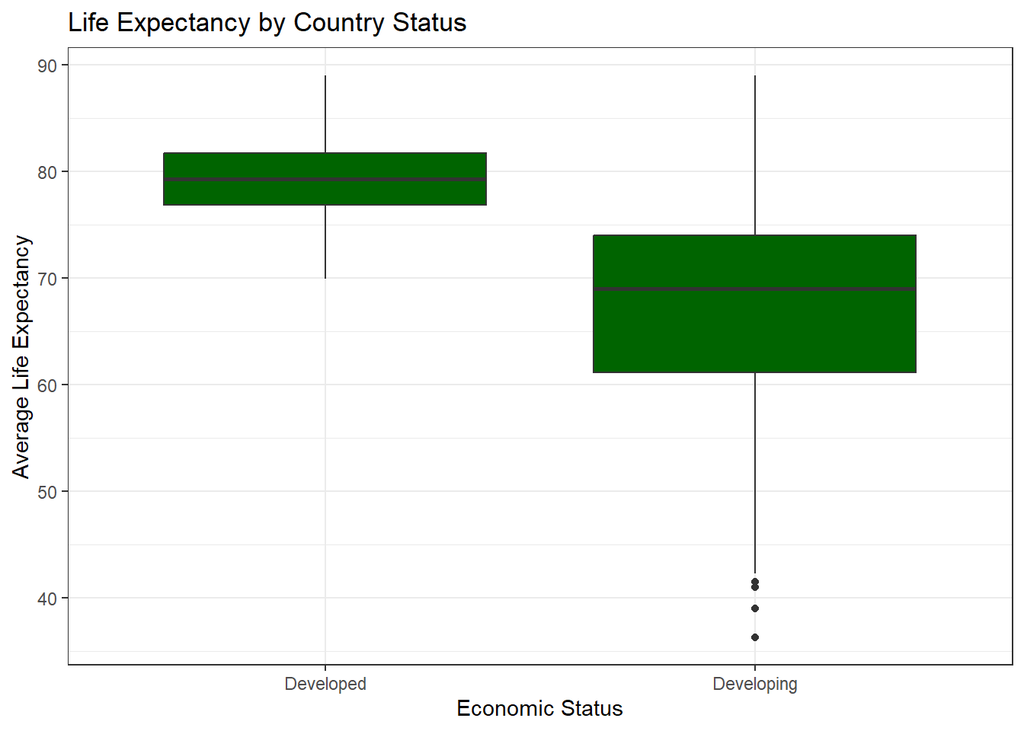

From our chart above, we can see that the bulk of the life expectancy values are distributed around the 75 - 85 years marks for developed countries. For developing countries however, the situation is slightly different with a higher proportion of the data distributed between 60 - 75 years range.

We however have some outliers with some country averaging life expectancy figures below 45 and as low as 36 years. Some of these countries were Haiti in 2010, after the devastating earthquake in Port-au-Prince caused widespread destruction and loss of life. Sierra Leone recorded the next lowest life expectancy rates due to a civil war, which lasted from 1991 to 2002, resulted in widespread violence, displacement, and human rights abuses.

It is also interesting to note that, the bulk of the outliers towards the lower end of the life expectancy scale consisted almost entirely of African countries with Malawi, Zambia, Zimbabwe, Lesotho, Angola, Eritrea, Central African Republic, Swaziland, Uganda, Botswana, Nigeria and Chad averaging some of the lowest figures. It must however be added that these figures were from the early 2000s and some of the main reasons for low life expectancy rates were political instability, civil wars, the prevalence of HIV/AIDS, tuberculosis and malaria as well as food insecurity due to droughts leading to malnutrition. To top it all off, was the limited access to healthcare facilities and services which resulted in increased mortality rates and lower life expectancy.

We would also analyze these metrics over time to see if there are certain patterns or insights we can draw from them. The metrics we will visualize as line and charts are:

- adult mortality,
- number of infant deaths,
- alcohol consumption,
- hepatitis B immunization coverage among 1 year olds,
- measles cases,
- deaths under 5,
- polio immunization coverage among 1 year olds,
- HIV/AIDS related deaths per 1000 live births,
- number of years of schooling

### Adult Mortality

WHO defines adult mortality as the rates of both sexes (probability of dying between 15 and 60 years per 1000 population).

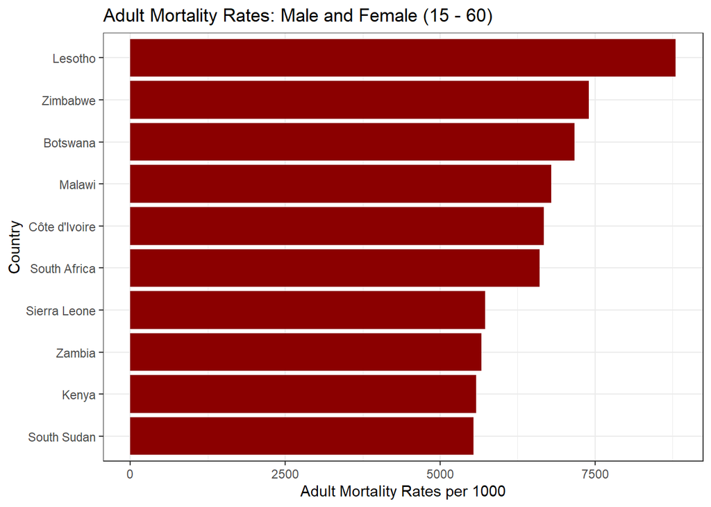

One common denominator among these top 10 countries as one of the main causes of deaths in adults is HIV/AIDS. This highly contagious and until recently, deadly disease is spread through sexual contact, sharing of needles, through childbirth from mother to child and through breastfeeding, among other ways, caused huge deaths in the late 1990s through the 2000s. The mode of spread took advantage of lack of education which led to stigmatization of the disease, causing infected people to not seek early care until it was too late, it also resulted in ignorance as most people did not know they were also infected until late on. The mechanism of the HIV/AIDS virus is such that, it attacks a victims immune system, rendering it very helpless to fight off other diseases. Add the onset of tuberculosis and other diseases such as malaria and that was a recipe for disaster.

Other major causes such as limited access to health care facilities. Without access to necessary medical care, individuals are more likely to suffer from preventable and treatable illnesses and conditions, such as infections, chronic diseases, and complications during pregnancy and childbirth. Limited access to healthcare can be due to a variety of reasons, including lack of infrastructure, inadequate funding, and insufficient healthcare workers.

Cultural or social barriers can hinder individuals from accessing medical care, limiting their ability to seek or receive necessary treatment. These barriers may arise from deep-rooted beliefs, traditions, or societal norms that discourage seeking medical help. Such obstacles can exacerbate health disparities and impede efforts to improve overall healthcare outcomes.

### Infant Deaths

Infant mortality remains a pressing global public health concern, claiming the lives of countless infants each year. This tragic outcome is attributable to a myriad of factors, encompassing limited healthcare access, pervasive poverty, infectious diseases, and the scourge of malnutrition. Despite overall progress in reducing global infant mortality rates over the past few decades, the trajectory has been inconsistent, with certain regions and countries still grappling with alarmingly high infant mortality rates. Consequently, addressing the root causes underlying infant mortality represents a critical challenge for the global healthcare system.

In our plot below, we visualize the top 10 countries worldwide that have borne the highest burden of infant deaths per 1000 live births.

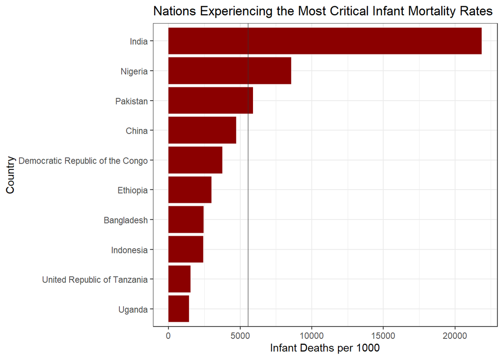

Regrettably, India emerges as the frontrunner in this distressing metric, bearing witness to a staggering toll of over 20,000 infant deaths during the 16-year period examined. Following closely behind, Nigeria, Pakistan, and China claim the unenviable ranks of second, third, and fourth, respectively, while the Democratic Republic of the Congo ranks fifth in this tragic tally.

The situation in India is undeniably tragic, as the number of infant deaths surpasses the very denominator employed to standardize this variable. This heartbreaking reality stems from a complex interplay of factors, including rampant malnutrition, alarmingly low rates of immunization, inadequate access to quality healthcare services, and pervasive poverty.

These pressing challenges extend beyond India’s borders, affecting other countries such as Nigeria and Pakistan that have also experienced infant mortality rates above the average figure during the period under analysis.

Conversely, amidst this distressing landscape, there are countries that have reported a remarkable achievement: no infant deaths per 1000 live births throughout the entire 16-year span of examination.

Their exceptional performance serves as a beacon of hope and underscores the immense potential for implementing effective strategies they employ and interventions to safeguard the lives of the most vulnerable members of society. These countries were:

- Antigua and Barbuda
- Austria
- Bahamas
- Bahrain
- Barbados
- Belarus
- Belize
- Bosnia and Herzegovina
- Brunei Darussalam
- Cabo Verde
- Croatia
- Cyprus
- Czechia
- Denmark
- Estonia
- Fiji
- Finland
- Grenada
- Iceland
- Ireland
- Kiribati
- Latvia
- Lithuania
- Luxembourg
- Maldives
- Malta
- Mauritius
- Micronesia (Federated States of)
- Montenegro
- New Zealand
- Norway
- Qatar
- Saint Lucia
- Saint Vincent and the Grenadines
- Samoa
- Sao Tome and Principe
- Seychelles
- Singapore
- Slovakia
- Slovenia
- Solomon Islands
- Suriname
- Sweden
- Switzerland
- The former Yugoslav republic of Macedonia
- Tonga
- Trinidad and Tobago
- Vanuatu

### Alcohol

Alcohol consumption is a complex factor that influences life expectancy, with both positive and negative impacts. While moderate drinking is associated with potential health benefits, excessive alcohol use can give rise to severe health issues, including liver disease, cancer, and cardiovascular disorders, which may ultimately diminish life expectancy.

However, it is crucial to acknowledge that the relationship between alcohol and life expectancy is multifaceted and influenced by various factors. Individual behaviors, socio-economic status, and cultural norms play significant roles in shaping this association. Striking a balance between moderate alcohol consumption and avoiding excessive use is widely recognized as essential for maintaining a healthy and prolonged life expectancy. It is noteworthy that certain cultures and religions, like Islam, strictly prohibit alcohol consumption as part of their core beliefs and practices.

Let us now explore the top 10 countries globally with the highest alcohol consumption rates.

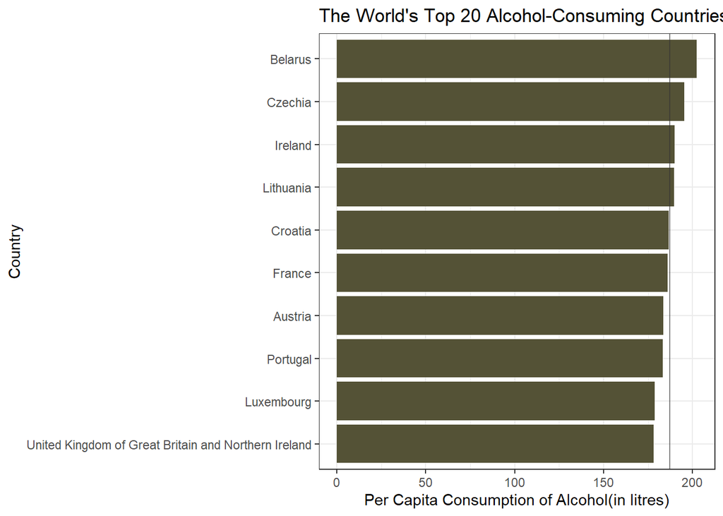

According to our plot, Belarus emerges as the country with the highest per capita consumption of pure alcohol in liters worldwide. The top 10 countries in this regard engage in a fiercely competitive race, with Czechia, Ireland, Lithuania, Croatia, France, Austria, Portugal, Luxembourg, and the UK comprising the rest of the elite group.

It is intriguing to consider the relationship between alcohol consumption and life expectancy within the context of Europe’s prominence. While Europe dominates the list of countries with the highest average life expectancy, it does not necessarily imply lower life expectancy rates. This observation raises the notion that numerous other factors, including healthcare systems, socio-economic conditions, lifestyle choices, and cultural aspects, significantly influence life expectancy outcomes.

Exploring the interplay between alcohol consumption, societal dynamics, and life expectancy provides valuable insights into the complex nature of public health and underscores the need for comprehensive approaches when analyzing health-related data.

### Hepatitis B Immunization Coverage

Hepatitis B, a viral infection that targets the liver, poses a grave threat to individuals worldwide, capable of causing liver damage, liver cancer, and even mortality. Its impact on life expectancy is influenced by various factors, including access to healthcare and vaccination programs. While there has been a decline in the number of Hepatitis B cases in recent decades, it remains a substantial public health challenge, particularly in low- and middle-income countries where vaccination rates are inadequate.

Addressing this global concern necessitates concerted efforts to prevent and control the spread of Hepatitis B. Education campaigns to raise awareness, widespread vaccination programs, and improved accessibility to quality healthcare play pivotal roles in improving public health outcomes. By implementing comprehensive strategies and prioritizing prevention and treatment, we can mitigate the burden of Hepatitis B and safeguard the well-being and longevity of individuals worldwide.

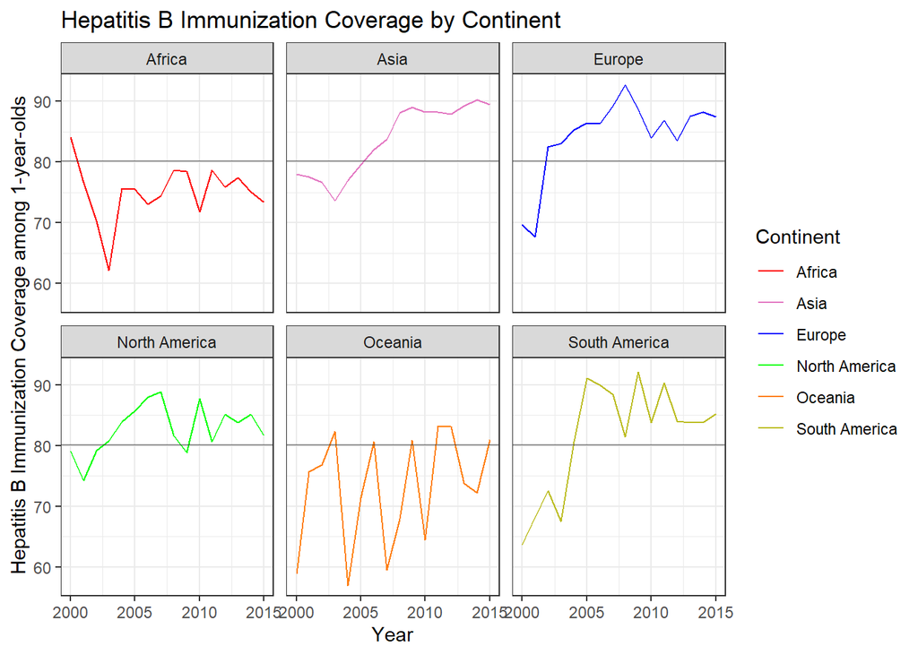

Africa initially started with the highest hepatitis B immunization coverage rates among all continents in 2000, boasting nearly 85% coverage. However, there was a steep decline to around 60% before gradually recovering to a decent coverage rate, although consistently lower than the global average.

Hepatitis B immunization among infants has proven remarkably successful in preventing transmission and reducing the global burden of hepatitis B. Routine vaccination programs have contributed to substantial declines in new infections, chronic cases, and associated complications. Early immunization in infancy establishes long-term protection and saves lives. This cost-effective intervention not only safeguards individual health but also contributes to public health by establishing herd immunity.

Hepatitis B immunization plays a pivotal role in global efforts to eliminate viral hepatitis. It effectively prevents vertical transmission from mother to child and interrupts the chain of transmission within communities. The importance of high vaccination coverage lies in its ability to prevent infections, reduce the burden of chronic liver disease, and actively work towards the ambitious goal of global hepatitis elimination.

Ensuring optimal immunization coverage against hepatitis B is crucial in safeguarding infants, communities, and future generations from the devastating impact of this disease. It is a vital component of comprehensive public health strategies aimed at mitigating hepatitis B’s long-term consequences and securing a healthier future for all.

### Measles

Measles, an exceptionally contagious viral disease, holds significant implications for public health, particularly in regions with constrained healthcare resources. This infectious ailment can lead to severe complications, including pneumonia, neurological damage, and fatal outcomes. Despite the existence of a highly effective vaccine, measles continues to pose a global threat, with outbreaks emerging in diverse areas.

Mitigating the incidence and impact of measles necessitates addressing the root causes contributing to low vaccination rates and limited healthcare accessibility. Socioeconomic factors, inadequate infrastructure, and challenges in reaching remote communities play crucial roles in hindering vaccination efforts. To combat measles effectively, comprehensive strategies are required, encompassing robust immunization campaigns, health education, and strengthening healthcare systems to ensure equitable access to vaccines and timely medical care.

Furthermore, international collaboration and support are essential in assisting countries with limited resources to enhance their vaccination programs and surveillance systems. By fostering partnerships and sharing best practices, we can work towards achieving measles elimination goals and safeguarding public health on a global scale.

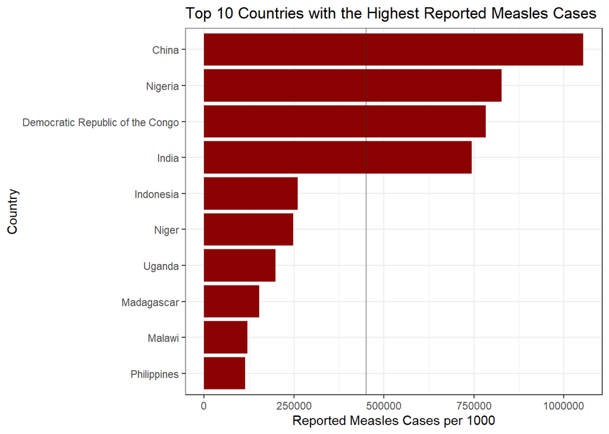

The plot above provides valuable insights into the countries burdened by reported measles cases, namely China, Nigeria, the Democratic Republic of the Congo (DRC), India, and Indonesia. Several key factors contribute to this situation, warranting attention and action.

One significant challenge is low vaccination coverage, with certain populations facing obstacles such as limited access to immunization services or vaccine hesitancy driven by various factors. Weak healthcare systems, inadequate infrastructure, and limited resources further compound the problem, hampering the efficient delivery of vaccination programs and surveillance initiatives.

The large population sizes of these countries amplify the scale of reported measles cases, creating additional complexities. Moreover, reaching remote or marginalized communities poses a formidable challenge due to geographical barriers, social disparities, and limited healthcare accessibility, further hindering vaccination efforts.

Effectively addressing these issues requires a multi-faceted approach. Strengthening immunization programs by expanding coverage, ensuring vaccine availability, and improving cold chain logistics is crucial. Enhancing healthcare infrastructure, including expanding healthcare facilities and training healthcare workers, is essential for delivering vaccines and providing comprehensive healthcare services.

Promoting community engagement and awareness through education, communication campaigns, and addressing vaccine hesitancy can help overcome barriers to vaccination. Establishing robust surveillance systems, including case detection, reporting, and response mechanisms, is vital to track and control measles outbreaks effectively.

International collaboration, technical assistance, and financial support play pivotal roles in assisting countries burdened by measles cases. By addressing these contributing factors comprehensively, we can strive towards reducing the burden of measles, increasing immunization coverage, and ultimately protecting the health and well-being of communities in these countries.

### Deaths Under 5

“Deaths under 5” is a pivotal metric used in public health and demographic studies to evaluate the mortality rates and overall welfare of children below the age of five. It serves as an informative indicator that sheds light on the health and survival of young children within a population.

This term encompasses the number of fatalities that occur during the crucial first five years of life, a period marked by significant physical, cognitive, and emotional development. By examining deaths under 5, researchers and policymakers gain crucial insights into child mortality rates, allowing them to identify regions or communities facing elevated risks and disparities in child survival.

Monitoring deaths under 5 plays a vital role in tracking progress towards global targets, such as the Sustainable Development Goals, which aim to reduce child mortality and improve child well-being. This indicator enables the assessment of healthcare systems’ effectiveness, including access to essential services like immunization, nutrition, and healthcare facilities. It also helps identify socio-economic factors, such as poverty, education, and infrastructure, that influence child health outcomes and survival.

By analyzing deaths under 5, stakeholders in public health and policy can pinpoint areas in need of targeted interventions and allocate resources effectively. Strategies aimed at reducing child mortality, such as improved maternal and child healthcare, enhanced access to quality healthcare services, and comprehensive early childhood development programs, can be developed and implemented based on this valuable indicator.

Ultimately, by closely monitoring deaths under 5 and implementing evidence-based interventions, we can strive to improve child well-being, reduce child mortality rates, and create a healthier and more prosperous future for the next generation.

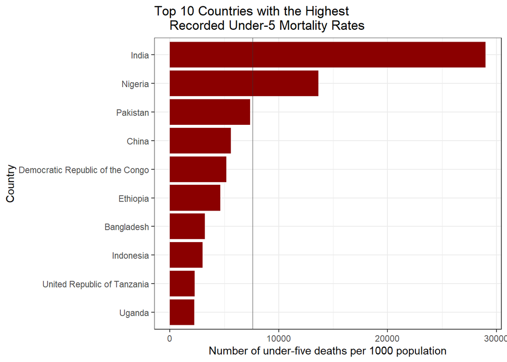

India, Nigeria, Pakistan, China, and the Democratic Republic of Congo (DRC) have encountered substantial hurdles in their quest to decrease child mortality rates, especially among children under the age of 5. Several interrelated factors contribute to these high rates, including malnutrition, prevalence of infectious diseases, gaps in immunization coverage, inadequate healthcare infrastructure, and socio-economic disparities.

Child mortality is exacerbated by malnutrition, which weakens the immune system and makes children more susceptible to illnesses and complications. Infectious diseases such as pneumonia, diarrhea, and malaria also play a significant role, as they are major causes of child deaths in these countries. Insufficient access to timely and complete immunization programs contributes to the vulnerability of children, leaving them unprotected against preventable diseases.

Limited healthcare infrastructure, including a shortage of skilled healthcare professionals, hampers the delivery of essential healthcare services, leading to delayed or inadequate treatment. Socioeconomic disparities further widen the gap, as marginalized communities face additional barriers in accessing healthcare and preventive interventions.

To address these challenges, efforts have been made to improve maternal and child healthcare through initiatives such as antenatal care, skilled birth attendance, and postnatal care. Expanding immunization coverage aims to protect children from vaccine-preventable diseases, while nutrition programs work to combat malnutrition and promote healthy growth. Strengthening healthcare systems, including enhancing infrastructure, training healthcare professionals, and ensuring the availability of essential medications and equipment, is vital.

While progress has been made, sustained efforts, collaboration among stakeholders, and increased investments are necessary to further reduce child mortality rates in these countries. This requires a multi-faceted approach, involving governments, international organizations, healthcare providers, and communities working together to address the complex challenges hindering child survival. By prioritizing child health, we can provide these children with a better chance at a healthy and prosperous life.

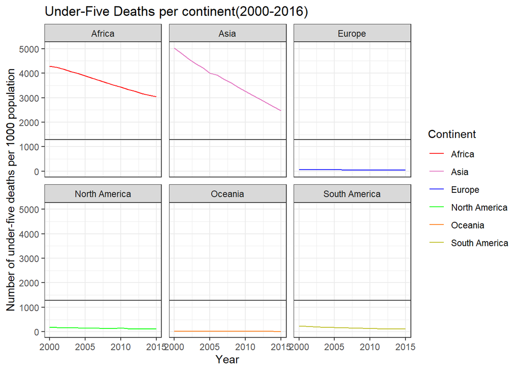

Fortunately, efforts to enhance child health and reduce avoidable deaths have led to a steady decline in the global mortality rate of children under five years old. This positive trend can be attributed to various factors, including the effective control and prevention of contagious diseases, advancements in maternal and child healthcare, a focus on improving nutrition, the development of healthcare infrastructure, and the implementation of sound policies.

Remarkable progress has been observed in regions such as Asia and Sub-Saharan Africa, where targeted initiatives have successfully tackled the unique challenges faced by these regions. By tailoring interventions to specific contexts, these areas have experienced notable improvements in child survival rates.

Interestingly, when examining deaths under the age of five across continents, Oceania consistently stands out as the region with the lowest number of child deaths. In stark contrast, Asia reported the highest number of child deaths under five in the year 2000, recording a total of 5,027 fatalities. These contrasting figures highlight the significant variations in child mortality rates across different regions.

The progress achieved in reducing child mortality globally serves as a testament to the effectiveness of comprehensive strategies that encompass various aspects of child health. Continued efforts to address the underlying causes of child mortality, promote access to quality healthcare, improve nutrition, and implement evidence-based policies are crucial to further enhance child survival rates and ensure a brighter future for children worldwide.

### Polio

Polio, a highly contagious viral disease, poses a significant threat to public health due to its easy transmission through contaminated sources. The virus can spread rapidly within communities, leading to widespread infections. The most severe consequence of polio is paralysis, which can result in lifelong disabilities, affecting mobility and independence, particularly in young children whose immune systems are still developing.

What makes polio even more dangerous is the absence of a cure. While supportive treatments can help manage symptoms and complications, there is no specific medication to eradicate the virus or reverse its effects. This underscores the critical role of vaccination in preventing polio and protecting individuals from its devastating consequences.

It is important to recognize that polio’s impact extends beyond borders. It can easily spread across countries and continents through travel and population movements, posing a risk of reintroduction even in regions that have successfully eliminated the disease. This emphasizes the ongoing need for comprehensive vaccination programs, surveillance systems, and global collaboration to ensure effective prevention and control of polio.

Significant efforts have been made to eradicate polio worldwide, including vaccination campaigns, robust surveillance, and community engagement. Through these collective endeavors, polio cases have been reduced, and outbreaks have been contained. By achieving global eradication, we can create a safer future where the threat of polio is eliminated, and the well-being of individuals, especially children, is protected from this dangerous disease.

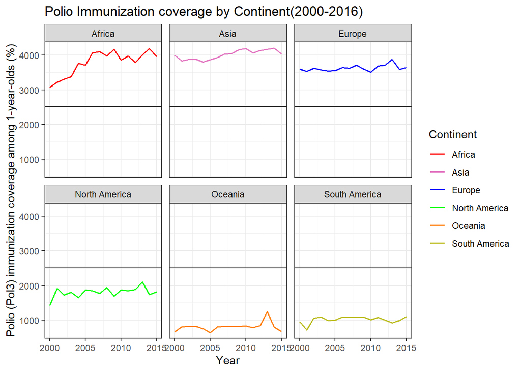

Europe, Africa, and Asia stand out as regions with the highest immunization coverage among 1-year-olds, reflecting the success of proactive government policies and well-functioning healthcare systems, particularly in Europe. Fruitful collaborations between local governments, healthcare providers, and international organizations, along with active public health campaigns, community outreach programs, and educational initiatives, have effectively raised awareness about the importance of vaccination. These efforts have addressed misconceptions and barriers that could hinder immunization, leading to high coverage rates.

Notably, several countries achieved impressive 99% immunization coverage by 2015, including Bolivia, Cuba, Fiji, Jordan, Maldives, Saint Lucia, Turkmenistan, and Albania. Their achievements demonstrate the effectiveness of focused immunization programs and the commitment to ensuring high vaccination rates.

Polio immunization plays a vital role in the global fight against the disease, providing long-lasting protection and preventing its spread. By vaccinating individuals, especially children, we significantly reduce the risk of polio infection and its devastating consequences.

The primary objective of polio immunization is global eradication, a goal that has made remarkable progress in reducing cases and declaring polio-free regions. Beyond individual protection, immunization contributes to community defense through herd immunity, where a high proportion of vaccinated individuals shields those who cannot be vaccinated.

Moreover, polio immunization enhances global health security by preventing the importation of cases. It is a cost-effective intervention that saves lives, reduces the burden on healthcare systems, and improves overall well-being.

The success of polio immunization campaigns offers valuable lessons for addressing other infectious diseases and strengthening healthcare systems and response capacities. It underscores the importance of comprehensive vaccination programs, strong partnerships, and sustained efforts to achieve optimal immunization coverage.

In conclusion, polio immunization is a critical tool in preventing and eradicating the disease. It provides long-lasting protection, contributes to global health security, is cost-effective, and offers insights and strategies for tackling future public health challenges. Prioritizing polio immunization not only saves lives but also creates a healthier world for generations to come.

### HIV AIDS

HIV, a viral infection that weakens the immune system, has had a significant impact on life expectancy, leading to substantial challenges in combating the HIV epidemic, which has resulted in a decline in life expectancy over the years.

Although progress has been made in combating the HIV epidemic and improving life expectancy, significant challenges persist. Factors such as the high prevalence of HIV, limited healthcare resources, and social and economic disparities continue to hinder the progress made in the countries most affected by the epidemic. Sustaining the gains achieved and further improving life expectancy requires ongoing efforts to address the underlying factors contributing to the spread of HIV.

To provide a visual representation of the impact of HIV/AIDS on child mortality, the plot below depicts HIV/AIDS-related deaths per 1000 live births among children aged 0 to 4. The animated plot showcases the trends in the countries hit hardest by the epidemic, illustrating the changes in HIV/AIDS-related child mortality rates over time.

This plot serves as a valuable tool for monitoring the effectiveness of interventions and identifying countries where targeted efforts are needed. By analyzing the trends in HIV/AIDS-related child mortality, policymakers, healthcare professionals, and researchers can gain insights into the progress made and areas that require further attention.

Through strategic interventions such as increased access to antiretroviral therapy (ART), prevention programs, and comprehensive healthcare services, it is possible to reduce HIV/AIDS-related child mortality and improve the overall well-being of affected communities. By focusing on the hardest-hit countries and implementing evidence-based strategies, we can continue the journey towards achieving sustainable improvements in life expectancy and ultimately ending the HIV epidemic.

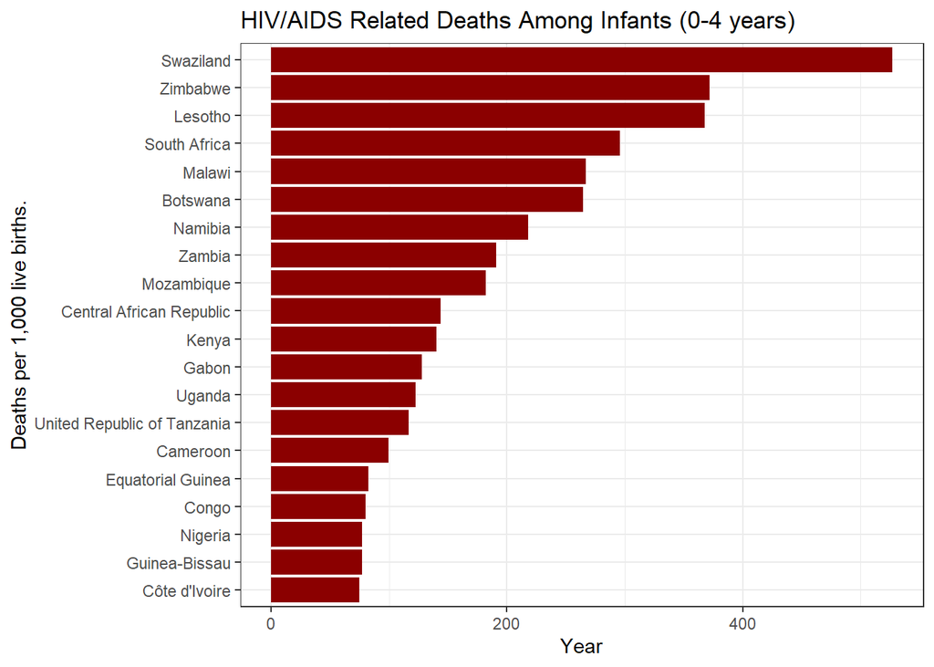

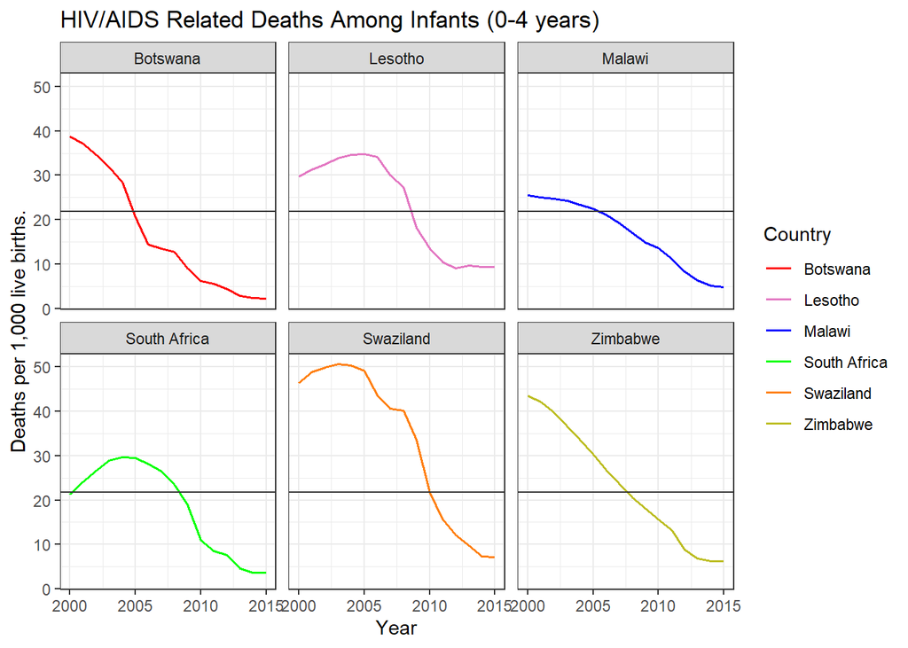

There is correlation between life expectancy and HIV/AIDS related mortalities per 1000 live births, particularly in countries heavily impacted by the HIV epidemic. Swaziland, Zimbabwe, Lesotho, South Africa, Malawi, and Botswana are among the nations with a high prevalence of HIV, resulting in an increased risk of transmitting the virus from mother to child.

Infants born to HIV-positive mothers have a greater chance of acquiring the infection and encountering complications that can lead to higher mortality rates. As a consequence, these countries often exhibit elevated mortality rates per 1000 live births compared to regions with lower HIV prevalence.

Recent efforts have been made to decrease the mortality rate per 1000 live births by preventing mother-to-child transmission of HIV and enhancing access to antiretroviral treatment for pregnant women. These initiatives aim to minimize HIV transmission from mothers to infants, ultimately improving child survival rates and reducing infant mortality associated with HIV.

However, addressing HIV-related deaths among children necessitates a comprehensive approach that involves early detection, suitable treatment, and continuous care and support. Additionally, endeavors to reduce mortality rates per 1000 live births in these countries should not solely concentrate on HIV but also take into account other factors that contribute to infant mortality, such as healthcare accessibility, nutrition, and overall socioeconomic conditions.

In conclusion, the impact of HIV on life expectancy is closely connected to the mortality rate per 1000 live births, particularly in countries significantly affected by the HIV epidemic. Progress has been made in preventing mother-to-child transmission of HIV and improving access to antiretroviral treatment, resulting in a decline in infant mortality rates. However, effectively addressing HIV-related deaths among children requires a comprehensive approach that addresses both HIV-specific factors and broader determinants of child health and well-being.

### Schooling

Education positively influences life expectancy by improving health literacy, access to healthcare, and promoting healthier behaviors. It also contributes to socioeconomic development, reducing poverty and improving healthcare access. Educated individuals can advocate for their rights and participate in community development, benefiting public health. Disparities in education can impact health outcomes and life expectancy. Investing in education can significantly improve population health and reduce health inequalities. Education empowers individuals to make informed health decisions and seek timely medical care. It promotes healthier choices, preventing chronic diseases and increasing life expectancy. Education is linked to socioeconomic development, providing better employment opportunities and access to quality healthcare. It enables active participation in community development and advocacy for health-related policies. Equitable access to education is essential for maximizing its impact on health outcomes. By investing in education, governments can create a healthier future for all.

We will investigate trends in schooling years patterns around the globe.

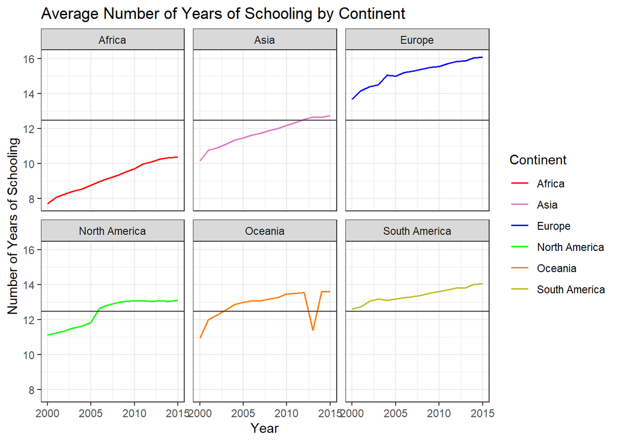

We can see that, for Africa, achieving above-average figures for years of schooling has been a persistent challenge. Several factors have hindered the continent’s progress, including limited access to education, economic difficulties, cultural and social norms, political instability, and gender disparities. These factors collectively contribute to Africa’s struggle in attaining higher levels of education.

Insufficient resources and inadequate infrastructure pose significant obstacles to educational advancement. Additionally, competing priorities divert attention and resources away from education. Societal norms and early marriage practices disproportionately affect girls, limiting their access to education. Furthermore, political instability and conflicts disrupt the educational system, further exacerbating the situation.

Addressing these challenges necessitates sustained efforts in various areas. Adequate funding must be allocated to education, enabling improvements in infrastructure and educational resources. Gender disparities must be addressed to ensure equal educational opportunities for girls. Promoting inclusive education that caters to diverse needs and backgrounds is essential. Finally, prioritizing education as a key driver of development and improved life expectancy is crucial.

By focusing on these areas and implementing comprehensive strategies, Africa can make significant progress in overcoming the barriers to education, ultimately leading to improved life expectancy and socioeconomic development across the continent.

## DATA MODELLING

We will utilize data modeling techniques to further analyze and interpret our data. Our primary goal is to unravel the intricate dynamics and correlations in our data and determining the significance of various predictors on life expectancy and identifying the variables that have the strongest influence on lifespan while debunking prevailing myths and misconceptions surrounding this critical measure of population health.

To achieve this, we will employ advanced statistical techniques, including linear regression and random forests.

Linear regression allows us to examine the linear associations between predictor variables and life expectancy, providing insights into the strength and direction of these relationships. On the other hand, random forests enable us to capture complex interactions and nonlinear relationships, offering a more comprehensive understanding of the determinants of longevity.

Throughout this section, we will explore the complexities of data modeling and its application in unraveling some ideas surrounding life expectancy. By harnessing the power of data and employing sophisticated modeling techniques, we aim to shed light on the underlying trends and correlations, challenge prevailing assumptions, and provide valuable insights for researchers, policymakers, and healthcare professionals.

The findings derived from data modeling hold great potential for informing evidence-based decision-making in public health, policy, and healthcare interventions. By identifying the most influential factors and their interactions, we can prioritize interventions that have the greatest potential to improve life expectancy and overall population health.

We will use empirical evidence and statistical analysis to pave the way to a deeper understanding of the factors shaping life expectancy, ultimately paving the path towards a healthier future for all.

```
##                                 .
## life_expectancy        1.00000000
## schooling              0.72763003
## income_comp_resources  0.72108259
## bmi                    0.54204159
## gdp                    0.44132181
## pct_expenditure        0.40963082
## alcohol                0.40271832
## diptheria              0.34133123
## polio                  0.32729440
## hepatitis_b            0.19993528
## total_expenditure      0.17471764
## population            -0.02230498
## measles               -0.06888122
## infant_deaths         -0.16907380
## deaths_under_5        -0.19226530
## thinness_5_9          -0.45750829
## thinness_1_19         -0.45783819
## hiv_aids              -0.59223629
## adult_mortality       -0.70252306
```

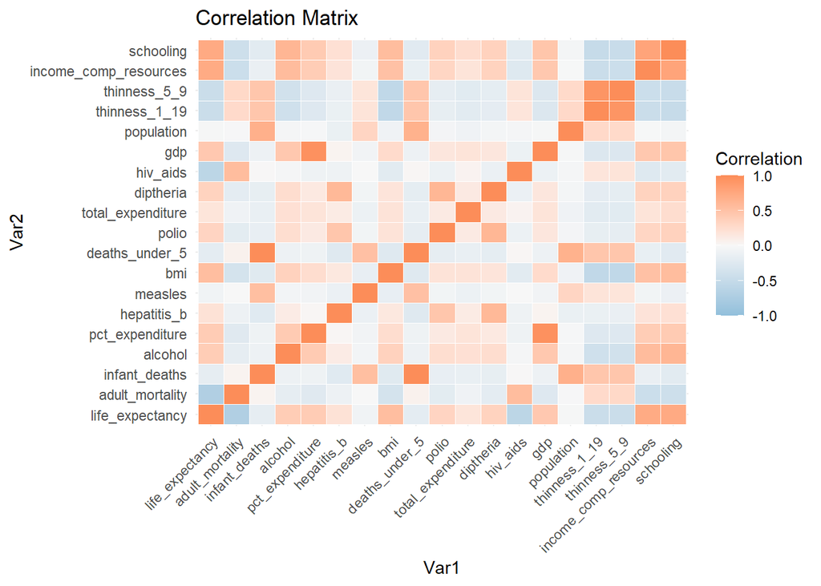

From the results of ´df.cor´,we can see that, schooling and a higher Human Development Index in terms of income composition of resources have the strongest positive relationship with life expectancy, which is expected as higher levels of education, reflected by more years spent schooling, positively impact life expectancy. Education provides health knowledge, access to healthcare, and empowers individuals to make informed decisions about their well-being. It reduces risky behaviors, such as smoking and excessive alcohol consumption and improves socioeconomic status, leading to better health outcomes and longer lives.

In the context of analyzing how a higher Human Development Index impacts life expectancy, the income composition of resources can be relevant because it reflects the economic conditions and resources available to a population. Higher income composition of resources generally indicates a more favorable economic environment, which can potentially support better healthcare services, nutrition, education, and overall well-being, all of which are factors that can contribute to higher life expectancy.

### Initial model

We will first build a linear regression model with all the variables in our data to determine alongside the above correlated variables, statistically significant variables that impact life expectancy.

We will then use our model to make predictions and evaluate our model performance using the metrics: Mean Standard Error (MSE) and R-squared (Coefficient of Determination).

Why? The MSE a measure of how well the predictions of a model match the actual values in a given dataset. It looks at the average difference between the predicted values and the actual values. Think of it as a way to measure how close the model’s predictions are to the real values.

A lower MSE means that the model’s predictions are closer to the actual values, which is generally better.

Also, R-squared is a measure of how much of the variability in the outcome variable (the thing we’re trying to predict: life expectancy) can be explained by the model’s input variables. It tells us how well the model fits the data. R-squared ranges from 0 to 1, where 1 means the model explains all the variation, and 0 means it doesn’t explain any.

So, a higher R-squared is generally better because it means the model is doing a good job of explaining the patterns in the data.

```
##
## Call:
## lm(formula = life_expectancy ~ ., data = train)
##
## Residuals:
##      Min       1Q   Median       3Q      Max
## -16.3980  -2.0944   0.1045   2.2014  12.1399
##
## Coefficients:
##                               Estimate       Std. Error t value
## (Intercept)           281.091854216144  56.410086240047   4.983
## year                   -0.114232286171   0.028158846325  -4.057
## adult_mortality        -0.015143339755   0.001111708131 -13.622
## infant_deaths           0.096964384220   0.012423803957   7.805
## alcohol                -0.101691059653   0.038044113229  -2.673
## pct_expenditure         0.000222328249   0.000198600449   1.119
## hepatitis_b            -0.001008253912   0.005102570589  -0.198
## measles                -0.000012374204   0.000011905890  -1.039
## bmi                     0.029481532534   0.007108516478   4.147
## deaths_under_5         -0.071739318764   0.008894901898  -8.065
## polio                   0.005539698557   0.006144614571   0.902
## total_expenditure       0.146727313374   0.049544294086   2.962
## diptheria               0.009872511943   0.007206478765   1.370
## hiv_aids               -0.457983360908   0.021148305573 -21.656
## gdp                     0.000033932402   0.000031158344   1.089
## population             -0.000000002047   0.000000001937  -1.057
## thinness_1_19           0.033618847451   0.062846174695   0.535
## thinness_5_9           -0.082801363121   0.062785077573  -1.319
## income_comp_resources  10.331135658746   0.974946034039  10.597
## schooling               0.969522524829   0.070642349855  13.724
##                                   Pr(>|t|)
## (Intercept)            0.00000072345911122 ***
## year                   0.00005317450789288 ***
## adult_mortality       < 0.0000000000000002 ***
## infant_deaths          0.00000000000001348 ***
## alcohol                            0.00763 **
## pct_expenditure                    0.26317
## hepatitis_b                        0.84340
## measles                            0.29887
## bmi                    0.00003614318585934 ***
## deaths_under_5         0.00000000000000185 ***
## polio                              0.36749
## total_expenditure                  0.00312 **
## diptheria                          0.17097
## hiv_aids              < 0.0000000000000002 ***
## gdp                                0.27637
## population                         0.29072
## thinness_1_19                      0.59280
## thinness_5_9                       0.18750
## income_comp_resources < 0.0000000000000002 ***
## schooling             < 0.0000000000000002 ***
## ---
## Signif. codes:  0 '***' 0.001 '**' 0.01 '*' 0.05 '.' 0.1 ' ' 1
##
## Residual standard error: 3.579 on 1134 degrees of freedom
## Multiple R-squared:  0.8355, Adjusted R-squared:  0.8328
## F-statistic: 303.2 on 19 and 1134 DF,  p-value: < 0.00000000000000022
```

```
## Mean Squared Error: 12.64972
```

```
## R-squared: 0.840298
```

Here, we developed a linear regression model to predict life expectancy based on all the other variables in our dataset.

The model explains approximately 84% of the variance in life expectancy, as indicated by the Adjusted R-squared value. This suggests that the model captures a substantial amount of the variability in the dependent variable.

Prediction accuracy: The residuals (differences between observed and predicted values) have a mean close to zero, indicating that the model is reasonably accurate in predicting life expectancy. The residual standard error provides an estimate of the average distance between the observed and predicted values, which is approximately 4 years.

Model significance: The F-statistic is highly significant (p < 0.001), indicating that the overall model is statistically significant and provides a better fit to the data than the null model.

```
##                  year       adult_mortality         infant_deaths
##              1.168501              1.679091            238.968142
##               alcohol       pct_expenditure           hepatitis_b
##              2.068434             10.677410              1.623751
##               measles                   bmi        deaths_under_5
##              1.496534              1.785217            225.115677
##                 polio     total_expenditure             diptheria
##              1.782363              1.177549              2.140246
##              hiv_aids                   gdp            population
##              1.441693             11.355915              2.278439
##         thinness_1_19          thinness_5_9 income_comp_resources
##              7.834135              8.135656              2.947786
##             schooling
##              3.643824
```

#### Issue with Multicollinearity

We used the VIF (Variance Inflation Factor) metric to measure the degree of multicollinearity between each predictor variable and the other variables in the model.

Generally, a VIF value of 1 indicates no multicollinearity, as it implies that the variable is not linearly correlated with the other predictors, whereas a VIF value greater than 1 indicates some level of multicollinearity, with higher values indicating stronger multicollinearity.

Based on tests conducted, multicollinearity does not affect the model performance so much and some of the variables are too conceptually important to be simply removed from our dataset so we still keep them for our initial model.

```
##
## Call:
## lm(formula = life_expectancy ~ ., data = train2)
##
## Residuals:
##     Min      1Q  Median      3Q     Max
## -17.371  -2.113   0.075   2.268  11.328
##
## Coefficients:
##                        Estimate Std. Error t value             Pr(>|t|)
## (Intercept)           52.555683   0.685070  76.716 < 0.0000000000000002 ***
## schooling              1.046267   0.069598  15.033 < 0.0000000000000002 ***
## income_comp_resources 10.275402   0.981417  10.470 < 0.0000000000000002 ***
## bmi                    0.034987   0.006736   5.194          0.000000243 ***
## alcohol                0.002231   0.036318   0.061                0.951
## adult_mortality       -0.016423   0.001128 -14.555 < 0.0000000000000002 ***
## deaths_under_5        -0.073255   0.008397  -8.724 < 0.0000000000000002 ***
## hiv_aids              -0.442752   0.021275 -20.811 < 0.0000000000000002 ***
## infant_deaths          0.096251   0.011361   8.472 < 0.0000000000000002 ***
## ---
## Signif. codes:  0 '***' 0.001 '**' 0.01 '*' 0.05 '.' 0.1 ' ' 1
##
## Residual standard error: 3.675 on 1145 degrees of freedom
## Multiple R-squared:  0.8249, Adjusted R-squared:  0.8237
## F-statistic: 674.3 on 8 and 1145 DF,  p-value: < 0.00000000000000022
```

```
## Mean Squared Error: 13.85454
```

```
## R-squared: 0.8248602
```

Given our r-squared values and our MSE, we can conclude that there is no substantial difference in the performance of the first model and the second model.

```
## Linear Regression
##
## 1154 samples
##    8 predictor
##
## No pre-processing
## Resampling: Cross-Validated (5 fold)
## Summary of sample sizes: 924, 923, 922, 924, 923
## Resampling results:
##
##   RMSE      Rsquared  MAE
##   3.706044  0.82439   2.841746
##
## Tuning parameter 'intercept' was held constant at a value of TRUE
```

Now that we have a baseline algorithm, we can use a comparison algorithm. For our dataset, Gradient Boosting, Support Vector Machines and Random Forests could all be used but since we want to go deep into our dataset, we will use the Random Forest Algorithm as our comparison model.

Random Forests are usually far more accurate than linear regression models, automatically measures feature importance, captures non-linear relationships that linear regression models fail to do and is less sensitive to outliers and quite resistant to overfitting since it uses bootstrapping, feature randomization and regularization.

We will initially build our model with all variables and narrow down to the important ones just like for the linear regression model.

```
##
## Call:
##  randomForest(formula = life_expectancy ~ ., data = train)
##                Type of random forest: regression
##                      Number of trees: 500
## No. of variables tried at each split: 6
##
##           Mean of squared residuals: 3.483175
##                     % Var explained: 95.45
```

```
## Mean Squared Error: 4.169969
```

```
## R-squared: 0.9487278
```

Our random forest model consisted of 500 decision trees, each making predictions on a subset of randomly selected variables. This ensemble approach allows the model to combine the predictions of multiple trees, resulting in more accurate and robust predictions. The number of variables tried at each split was set to six, ensuring a diverse set of features were considered during the model’s training process.

Another important metric is the percentage of variance explained by the model, which was determined to be 95.45%. This indicates that the random forest model captures a significant portion of the variability in the life expectancy data. In other words, it effectively accounts for the factors influencing life expectancy and provides a comprehensive understanding of the relationship between the input variables and the target variable.

To further evaluate the model’s performance, the mean squared error (MSE) and the R-squared coefficient were calculated. The MSE was found to be 4.169969 years, indicating that the model’s predictions deviated from the actual values by this amount squared, on average. This lower MSE value suggests better accuracy and a closer fit to the observed data.

The R-squared coefficient, which ranges from 0 to 1, measures the proportion of the variance in the life expectancy that can be explained by the model. In this case, the R-squared value was determined to be 0.9487278. This implies that approximately 94.87% of the variability in life expectancy can be attributed to the input variables included in the model. A higher R-squared value indicates a better fit and suggests that the model captures a substantial portion of the underlying relationships.

In summary, the random forest model demonstrated strong performance in predicting life expectancy. With its ensemble approach and consideration of multiple input variables, the model achieved low prediction errors (MSE), high variance explained, and a high R-squared coefficient. These results provide evidence that the random forest algorithm is well-suited for this task and can effectively capture the complex relationships between the input variables and life expectancy.

```
##                       IncNodePurity
## year                       479.0628
## adult_mortality          15185.5527
## infant_deaths             1185.3917
## alcohol                   1450.2980
## pct_expenditure           1515.9232
## hepatitis_b                315.9488
## measles                    405.6297
## bmi                       4482.2146
## deaths_under_5            1997.8673
## polio                      542.4534
## total_expenditure         1094.1140
## diptheria                  446.3495
## hiv_aids                 20068.1302
## gdp                        997.5465
## population                 391.3879
## thinness_1_19             2547.3746
## thinness_5_9              3295.0839
## income_comp_resources    22407.1479
## schooling                 9242.2159
```

Policy makers, researchers and donors should prioritize addressing the composite measure of income and resources, adult mortality rate, HIV/AIDS prevalence, and schooling to increase life expectancy. By focusing on these factors, they can significantly impact health outcomes and promote longer, healthier lives.

Improving income and resources supports better healthcare infrastructure, access to quality services, and improved living conditions. Reducing adult mortality through healthcare interventions, disease prevention, and health promotion programs is crucial. Targeting HIV/AIDS prevalence through prevention, treatment, and comprehensive care can have a profound impact on life expectancy.

Investing in education enables individuals to make informed health decisions, adopt healthier behaviors, and contribute to economic development. These variables play a vital role in shaping health outcomes and should be the focal point for policies and interventions aimed at increasing life expectancy.

By allocating resources, designing evidence-based interventions, and implementing targeted programs, policy makers and donors can address the root causes of low life expectancy. Prioritizing these factors holds the potential to create significant improvements in population health, reduce disparities, and pave the way for a healthier future for communities and nations.

The data analysis, research, and writing for this project were conducted by: [Jeffrey Ohene](https://www.jeffreyohene.net)